# Gráficos Q-Q

La idea de los gráficos Q-Q es ver si una muestra sigue una distribución normal y para ello conoceremos la función **qnorm**. Primero vamos a crear una secuencia de números, que empiece en 0,01 y llegue a 0,99, subiendo de 0,01 en 0,01. Esta secuencia nos servirá también como percentiles.

Posteriormente, aplicaremos la función **qnorm**, cuyo argumento principal es un vector de cuantiles/percentiles (es decir, la secuencia anterior). Finalmente, guardaremos los datos en un dataframe con dos columnas, dadas por los percentiles y su probabilidad asociada.

```r
s <- seq(0.01, 0.99, 0.01)
qn <- qnorm (s)

df <- data.frame (p=s, q=qn)
```

Ahora, vamos a sacar una muestra *random* haciendo uso de la función **rnorm**. Con la función **quantile** podemos calcular cada percentil y los valores que les corresponde

```r
sp <- rnorm(200)
sp
```

[output not shown]

```r
quantile (sp, probs = s)
```

```
          1%           2%           3%           4%           5%           6%           7%           8%           9%
-2.015428111 -1.885986449 -1.843416758 -1.772167647 -1.732808509 -1.587602725 -1.572419974 -1.496030955 -1.460374537
         10%          11%          12%          13%          14%          15%          16%          17%          18%
-1.434067864 -1.348271796 -1.325613061 -1.288867054 -1.244606213 -1.191026031 -1.145306990 -1.101024079 -1.080840786
         19%          20%          21%          22%          23%          24%          25%          26%          27%
-1.026500312 -1.019807013 -0.941385176 -0.915816318 -0.875453147 -0.856980922 -0.840961425 -0.823321896 -0.805339078
         28%          29%          30%          31%          32%          33%          34%          35%          36%
-0.792782119 -0.771558318 -0.758813499 -0.715254855 -0.684396760 -0.607079048 -0.601434252 -0.546597996 -0.529883503
         37%          38%          39%          40%          41%          42%          43%          44%          45%
-0.505908219 -0.478835611 -0.457838396 -0.442724085 -0.394078037 -0.358498510 -0.282337469 -0.267084911 -0.242124993
         46%          47%          48%          49%          50%          51%          52%          53%          54%
-0.233804148 -0.182304182 -0.160133612 -0.142922463 -0.107169250 -0.060839229 -0.044558864 -0.013408976  0.003269778
         55%          56%          57%          58%          59%          60%          61%          62%          63%
 0.012008271  0.050263516  0.062186004  0.081894709  0.146187817  0.153501319  0.182336736  0.212957286  0.254888863
         64%          65%          66%          67%          68%          69%          70%          71%          72%
 0.271649115  0.290493434  0.319859128  0.353785399  0.380884011  0.427955618  0.490391569  0.504941193  0.513450133
         73%          74%          75%          76%          77%          78%          79%          80%          81%
 0.537276062  0.562212552  0.611418405  0.639711554  0.836319508  0.849001374  0.882211599  0.907632400  0.969736653
         82%          83%          84%          85%          86%          87%          88%          89%          90%
 1.090648005  1.127088120  1.157519978  1.162940378  1.216930960  1.288930102  1.362983382  1.411636964  1.468105249
         91%          92%          93%          94%          95%          96%          97%          98%          99%
 1.511739080  1.581318293  1.713834774  1.728405855  1.969306292  2.049206698  2.149380818  2.275443391  2.493729428
```

Para crear gráficos usaremos **qqnorm* y** qqplot**. Veamos el uso de** qqnorm** (que hace un plot frente a una distribución teórica normal), usando el dataset *trees* (árboles) que viene en R y que tiene algunos valores. Nos preguntamos si la altura de los árboles (medida en este dataset) sigue una distribución normal. Para ello:

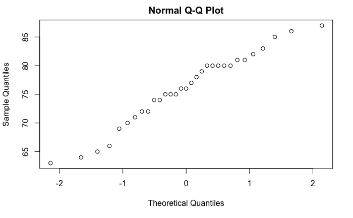

```r
qqnorm(trees$Height)
```